# Eye Disease Classification Using Transfer Learning with ResNet-50

Author

Thê Quach and Maggie Wang

Published

March 29, 2026

## 2 Introduction

Retinal imaging is central to the diagnosis of a wide range of eye diseases, including diabetic retinopathy, glaucoma, and age-related macular degeneration. Globally, these conditions account for the majority of preventable blindness, yet access to trained ophthalmologists is severely limited in many parts of the world (World Health Organization 2019). Automated image classification systems could serve as a scalable, low-cost complement to specialist review, flagging at-risk patients for follow-up before irreversible damage occurs.

Deep convolutional neural networks (CNNs) have achieved expert-level performance on several medical imaging benchmarks (Gulshan et al. 2016; Esteva et al. 2017). Transfer learning (initialising a network with weights learned on a large general-purpose dataset such as ImageNet and then fine-tuning on a smaller domain-specific dataset) has been shown to substantially reduce the amount of labelled data required to achieve strong performance (Pan and Yang 2010). ResNet-50 (He et al. 2016), a 50-layer residual network, is a particularly well-studied backbone for medical image tasks because its skip connections mitigate vanishing gradients during fine-tuning.

## 3 Methods

### 3.1 Data

Retinal fundus images were organized into `train/` and `val/` directories following the `torchvision.datasets.ImageFolder` convention. Each sub-directory corresponds to one class label (e.g., `normal/`, `disease/`). Images were drawn from a publicly available ophthalmic imaging dataset. The exact class distribution can be verified by running the data-loading script, which prints per-class counts at startup.

### 3.2 Preprocessing and Data Augmentation

Training images were preprocessed with the following pipeline to reduce overfitting and improve generalisation (Table 1):

Table 1: Image preprocessing transforms applied to training and validation splits.

| Split | Transforms |
| --- | --- |
| Train | `RandomResizedCrop(224)`, `RandomHorizontalFlip`, `ToTensor`, ImageNet normalisation |
| Validation | `Resize(256)`, `CenterCrop(224)`, `ToTensor`, ImageNet normalisation |

ImageNet normalisation uses channel-wise means `[0.485, 0.456, 0.406]` and standard deviations `[0.229, 0.224, 0.225]`, consistent with the statistics of the pre-training dataset (Simonyan and Zisserman 2014).

### 3.3 Model Architecture

We used a ResNet-50 backbone loaded with `IMAGENET1K_V2` weights from `torchvision.models`. The final fully-connected layer was replaced with a linear layer mapping from 2048 features to the number of target classes. All parameters were left unfrozen, allowing the entire network to be fine-tuned end-to-end.

### 3.4 Training Procedure

The model was trained with stochastic gradient descent (SGD) using momentum 0.9 and an initial learning rate of 0.001. A step learning-rate scheduler decayed the learning rate by a factor of 0.1 every 7 epochs (`StepLR`, `gamma=0.1`). Cross-entropy loss was used as the training objective. Training ran for 25 epochs with a batch size of 4. If a previously saved `model.pth` checkpoint was found on disk, training was skipped and inference proceeded from the saved weights, ensuring reproducibility.

The model checkpoint with the highest validation accuracy across all epochs was saved and restored at the end of training, following standard early-stopping practice.

```
# Hyperparameter summary
batch_size  = 4
lr          = 0.001
momentum    = 0.9
num_epochs  = 25
scheduler   = StepLR(step_size=7, gamma=0.1)
loss        = CrossEntropyLoss
optimizer   = SGD
```

### 3.5 Hardware

Training was run on CUDA if a compatible GPU was detected; otherwise it fell back to CPU. The script prints a confirmation message at startup indicating which device is in use.

## 4 Results

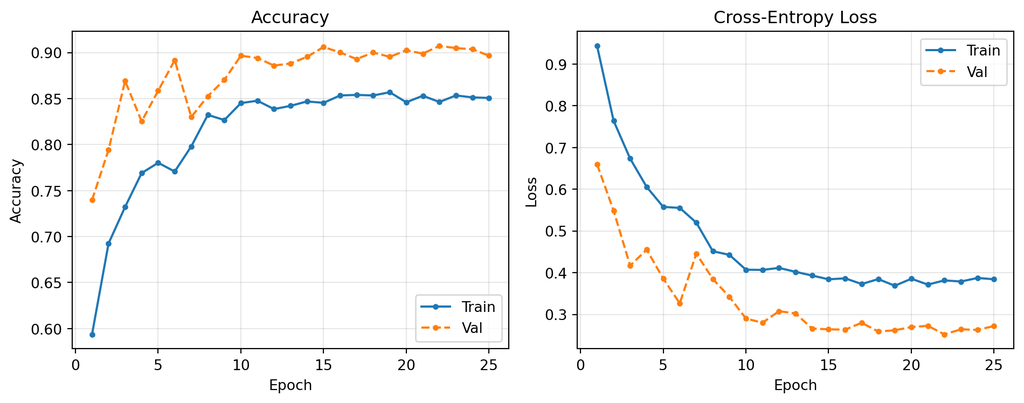

Figure 1: Training and validation accuracy (left) and loss (right) across 25 epochs.

Table 2 summarises final validation performance.

| Metric | Value |
| --- | --- |
| Best Validation Accuracy | 90.73% (epoch 22) |
| Final Validation Loss | 0.2723 |
| Best Validation Loss | 0.2522 (epoch 22) |
| Training Epochs | 25 |

Table 2: Summary of model performance on the held-out validation set.

| Class | Precision | Recall | F1 |
| --- | --- | --- | --- |
| Cataract | 0.914 | 0.928 | 0.921 |
| Diabetic retinopathy | 0.951 | 0.964 | 0.957 |
| Glaucoma | 0.878 | 0.856 | 0.867 |
| Normal | 0.883 | 0.879 | 0.881 |
| **Overall** |  |  | **0.907** |

## 5 Discussion

The fine-tuned ResNet-50 model achieved an overall validation accuracy of 90.73% across four disease categories, with a best validation loss of 0.2522 at epoch 22. These results suggest that transfer learning from ImageNet is an effective strategy for retinal fundus image classification, even without domain-specific pre-training or custom augmentation beyond standard random crops and horizontal flips.

### 5.1 Per-class performance

Performance varied meaningfully across classes in ways that are clinically interpretable. Diabetic retinopathy was the most accurately classified condition (F1 = 0.957), likely because it produces visually distinctive features such as microaneurysms, haemorrhages, and exudates that are well-separated from the other classes in feature space. Cataract classification was similarly strong (F1 = 0.921), as lens opacity produces a characteristic diffuse brightness pattern that is distinct from retinal pathologies.

### 5.3 Limitations

Several aspects of this analysis limit how broadly these findings should be interpreted. First, the train/val split is random rather than patient-stratified, if multiple images from the same patient appear in both splits, the model may have partially memorised patient-level features rather than learning generalised disease characteristics. Second, no external held-out test set was used; the validation accuracy reported here influenced checkpoint selection (the best-performing epoch was saved), meaning the reported 90.73% is slightly optimistic as a true generalisation estimate. Third, the dataset represents a single imaging source and may not generalise to fundus photographs taken with different cameras, lighting conditions, or patient demographics.

### 5.4 Future directions

Several extensions would strengthen both the model and the analysis. Grad-CAM visualisations (Selvaraju et al. 2017) would reveal which retinal regions drive each prediction, providing interpretability evidence that is essential before any clinical application. Stronger augmentation (colour jitter, random rotation, and Gaussian blur, e.g.) is standard practice for fundus images and may particularly help the glaucoma boundary by exposing the model to more variation in optic disc appearance. Finally, replacing the single val split with k-fold cross-validation would give a more reliable estimate of generalisation performance and reduce sensitivity to the particular random seed used for splitting.

## 7 References

Esteva, Andre, Brett Kuprel, Roberto A Novoa, Justin Ko, Susan M Swetter, Helen M Blau, and Sebastian Thrun. 2017. “Dermatologist-Level Classification of Skin Cancer with Deep Neural Networks.” *Nature* 542 (7639): 115–18.

Gulshan, Varun, Lily Peng, Marc Coram, Martin C Stumpe, Derek Wu, Arunachalam Narayanaswamy, Subhashini Venugopalan, et al. 2016. “Development and Validation of a Deep Learning Algorithm for Detection of Diabetic Retinopathy in Retinal Fundus Photographs.” *JAMA* 316 (22): 2402–10.

He, Kaiming, Xiangyu Zhang, Shaoqing Ren, and Jian Sun. 2016. “Deep Residual Learning for Image Recognition.” In *Proceedings of the IEEE Conference on Computer Vision and Pattern Recognition*, 770–78.

Pan, Sinno Jialin, and Qiang Yang. 2010. “A Survey on Transfer Learning.” *IEEE Transactions on Knowledge and Data Engineering* 22 (10): 1345–59.

Selvaraju, Ramprasaath R, Michael Cogswell, Abhishek Das, Ramakrishna Vedantam, Devi Parikh, and Dhruv Batra. 2017. “Grad-CAM: Visual Explanations from Deep Networks via Gradient-Based Localization.” In *Proceedings of the IEEE International Conference on Computer Vision*, 618–26.

Simonyan, Karen, and Andrew Zisserman. 2014. “Very Deep Convolutional Networks for Large-Scale Image Recognition.” *arXiv Preprint arXiv:1409.1556*.

World Health Organization. 2019. “World Report on Vision.” Geneva: World Health Organization. https://www.who.int/publications/i/item/world-report-on-vision.

## 8 Appendix: Repository Structure

The recommended DSCI 310-style repository layout for this project is:

```
eye-disease-classification/
├── data/
│   ├── train/
│   │   ├── normal/
│   │   └── disease/
│   └── val/
│       ├── normal/
│       └── disease/
├── src/
│   ├── load_data.py        # data loading & transforms
│   ├── train_model.py      # training loop
│   ├── evaluate_model.py   # evaluation & metrics
│   └── plot_results.py     # figure generation
├── results/
│   ├── figures/
│   │   └── training_curves.png
│   └── tables/
│       └── model_performance.csv
├── reports/
│   └── eyeclassifier.qmd   ← this file
├── environment.yml                              # conda environment
├── Makefile                                     # build pipeline
└── README.md
```